# Lab 2

Tracie-Lynn Lamoreux, Macy Schanbacher, Nic Rhoads

2023-03-02

1. What is the overall number of chocolate bars rated?

```r
nrow(choco)
```

```
## [1] 1852
```

2. How does the number of ratings depend on the year? Draw a bar chart of the number of reports

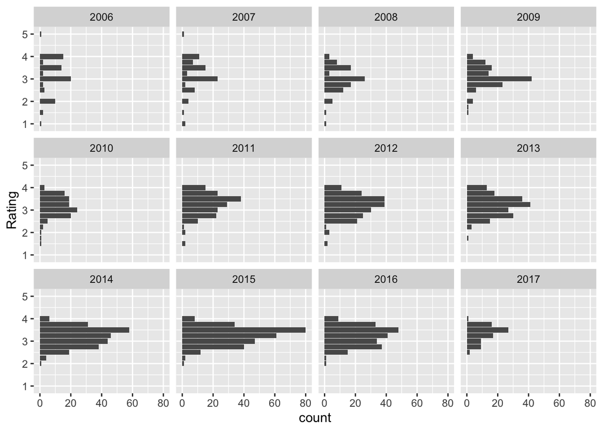

```r
ggplot(data=choco,aes(y=Rating))+ geom_bar()+ facet_wrap(~Review.Date)
```

*It seems the ratings for each year go up until the year 2015, and then drop after.

Questions set 2: 1. For each of the questions below provide at least one graphic as a basis for your answer. a. How are ratings distributed? Draw a histogram of ratings and describe it.

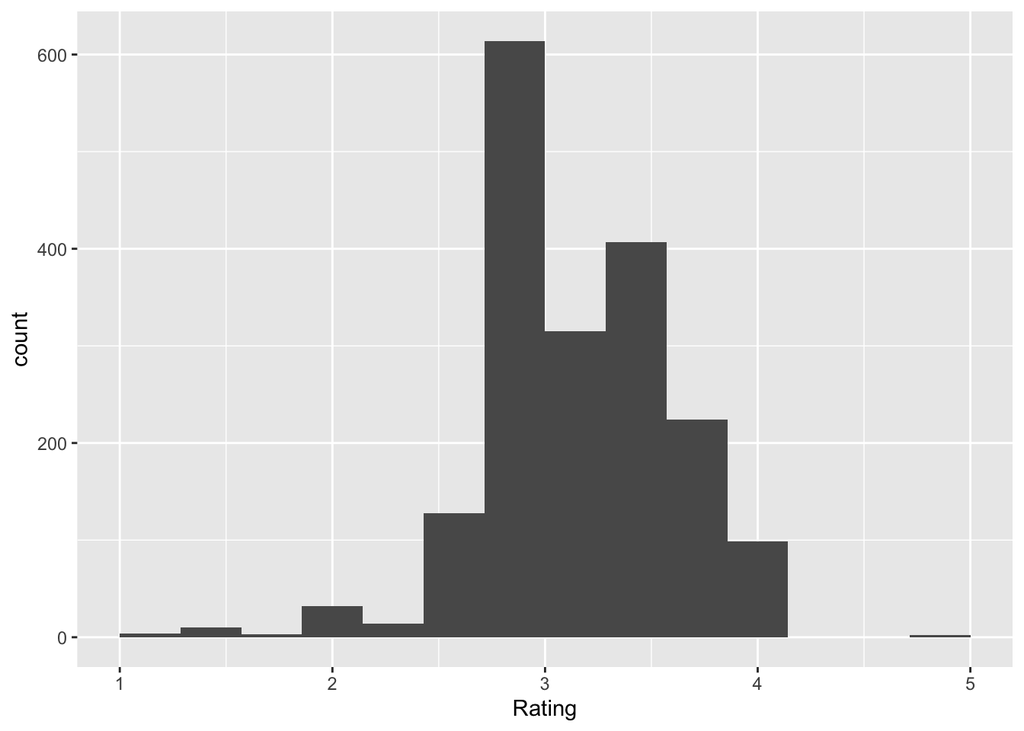

```r
ggplot(data=choco,aes(y=Rating))+geom_histogram(bins=15)+coord_flip()
```

*It is slightly skewed, but for the most part symmetrical, and bimodal. b. Do ratings depend on the cocoa percentage of a chocolate bar?

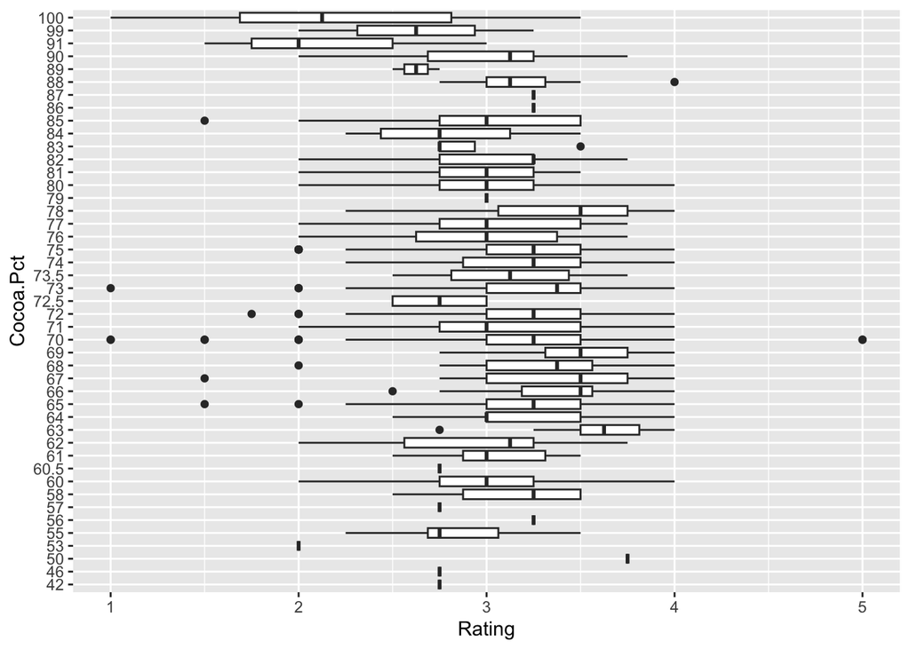

```r
choco$Cocoa.Pct<- as.factor(choco$Cocoa.Pct)
ggplot(data=choco, aes(x=Cocoa.Pct,y=Rating))+geom_boxplot()+coord_flip()
```

*The 100% cocao seems to have lower ratings, but for the most part the variation in each rating fluctuates and does increase nor decrease with an increase in cocao percentage. c. How do ratings compare across different company locations? Focus on the three locations with the most ratings.

[figure not shown]

```r
df<- dplyr::filter(choco, Company.Location %in% c("U.S.A.", "France", "Canada"))
ggplot(data=df,aes(x=Company, y= Rating))+geom_boxplot()+coord_flip()
```

Macy’s Question What type of choco bean has the highest rating out of the top three bean types (Trinitario, Criollo, Forastero) ?

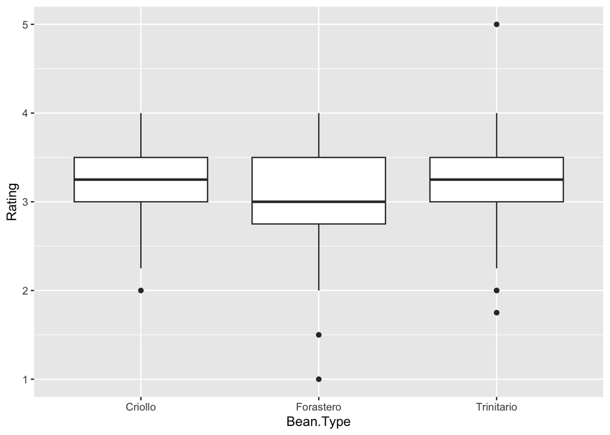

```r
bean_types = dplyr::filter(choco, Bean.Type %in% c("Trinitario", "Criollo", "Forastero"))
ggplot(bean_types, aes(x = Bean.Type, y = Rating)) + geom_boxplot()
```

In this graph we see that there is not much of a difference between the type of bean used and the rating. Most of the ratings fall in between the 3 - 3.5 ratings. The Forastero bean is very slightly lower than the others but the ratings for the Criollo and Trinitario beans are very similar.

Nic’s question: does the year the review was made affect the rating of the cocoa?

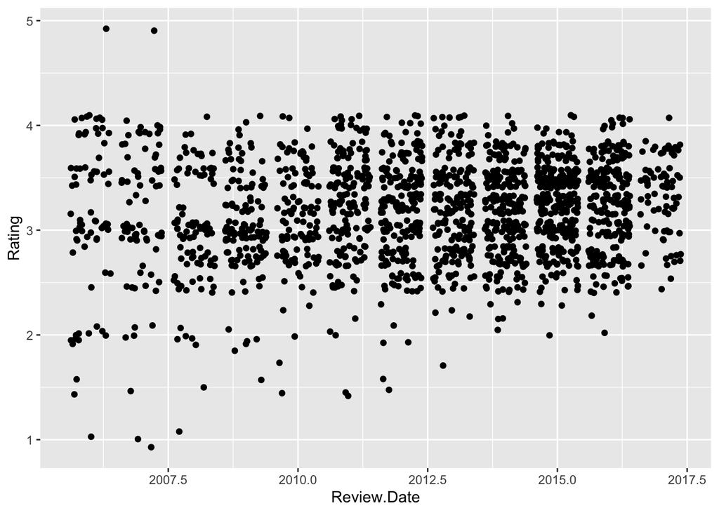

```r
ggplot(data = choco, aes(x = Review.Date, y = Rating)) + geom_point(position="jitter")
```

Yes, the average goes up over time. The values are also more condensed towards the average, as they were more spread out in early years.

Tracie-Lynn’s Question: Does Bean Origin Affect Cacao Percentage?

[figure not shown]

```r
choco$Cocoa.Pct<- as.numeric(choco$Cocoa.Pct)
ggplot(data=choco, aes(x=Broad.Bean.Origin,y=Cocoa.Pct))+geom_boxplot()+coord_flip()
```

Workflow comments: The workflow between us was very efficient. It was helpful because we each had a different prespective that led us to question different aspects of the dataset. It was also useful because we each had different experiences using github as well as R. Since we all had different experiences leading to the conclusions drawn to this homework assignment, it felt like we each offered information to help the progress of the homework assignment.